# Bài tập tuần 6: Phân tích thành phần chính - Thành phần nhân tố

nguyenthithanhhuong

2024-04-04

#### **Bài 8.1**

Đọc dữ liệu:

```r
path <- "D:/Code/r/mat3452/week06/data/investment.txt"
invest <- read.table(path, header = TRUE)
invest <- invest[, -1]
head(invest)
```

```
##   S.US S.Non.US S.Dev. B.US B.Non.US B.Dev. A.native A.Cash
## 1   45        3     17   35        0      0        0      0
## 2   28        6      9   30        3      0       24      0
## 3   53        9      3   28        1      1        0      5
## 4   26        9     10   30        0      0       25      0
## 5   19        9      3   20        4      5       34      6
## 6   29       13     12   19        3      0       20      4
```

Tìm giá trị riêng của ma trận tương quan:

```r
eigen(cor(invest))$values
```

```
## [1] 2.620514433 1.418999471 1.245032741 0.861633026 0.763012129 0.682940828
## [7] 0.406408810 0.001458563
```

Tìm vector riêng của ma trận tương quan:

```r
eigen(cor(invest))$vectors
```

```
##            [,1]        [,2]          [,3]         [,4]        [,5]
## [1,]  0.4306479  0.53126001  0.0985697073  0.002527855  0.34006529
## [2,] -0.3005817  0.08250428  0.6466365188  0.335992328 -0.15372920
## [3,]  0.3426365 -0.40468049  0.0009292256  0.203496275 -0.02814756
## [4,]  0.3798292 -0.34405750  0.0401090053 -0.102124827 -0.65907637
## [5,] -0.4479078 -0.12944658  0.3756732525 -0.061093269 -0.04581282
## [6,] -0.1878740  0.50762920 -0.1579860860 -0.450692477 -0.54215358
## [7,] -0.4386932 -0.32636352 -0.4289628342 -0.222364279  0.23888448
## [8,] -0.1848061  0.21876245 -0.4695066778  0.760894593 -0.26917258
##               [,6]       [,7]       [,8]
## [1,]  0.0008932807 -0.1762321 0.61309042
## [2,]  0.1319979884  0.5099298 0.26595029
## [3,] -0.7684827969  0.2235349 0.18999056
## [4,]  0.3797816501 -0.1779132 0.33918607
## [5,] -0.3061671859 -0.7117689 0.18790229
## [6,] -0.3741848725  0.1974843 0.07738062
## [7,]  0.1176319440  0.2181039 0.59085339
## [8,] -0.0136339080 -0.1846852 0.10883111
```

```r
sqrt(eigen(cor(invest))$values)
```

```
## [1] 1.61880031 1.19121764 1.11581035 0.92824190 0.87350565 0.82640234 0.63750201
## [8] 0.03819113
```

Xác minh rằng các giá trị này giống như các giá trị được nhận từ các thành phần chính bằng câu lệnh:

```r
princomp(invest, cor = TRUE)
```

```
## Call:
## princomp(x = invest, cor = TRUE)
##
## Standard deviations:
##     Comp.1     Comp.2     Comp.3     Comp.4     Comp.5     Comp.6     Comp.7
## 1.61880031 1.19121764 1.11581035 0.92824190 0.87350565 0.82640234 0.63750201
##     Comp.8
## 0.03819113
##
##  8  variables and  27 observations.
```

#### **Bài 8.2**

Đọc bộ dữ liệu Harmon23.cor:

```r
library(datasets)
data("Harman23.cor")
head(Harman23.cor)
```

```
## $cov
##                height arm.span forearm lower.leg weight bitro.diameter
## height          1.000    0.846   0.805     0.859  0.473          0.398
## arm.span        0.846    1.000   0.881     0.826  0.376          0.326
## forearm         0.805    0.881   1.000     0.801  0.380          0.319
## lower.leg       0.859    0.826   0.801     1.000  0.436          0.329
## weight          0.473    0.376   0.380     0.436  1.000          0.762
## bitro.diameter  0.398    0.326   0.319     0.329  0.762          1.000
## chest.girth     0.301    0.277   0.237     0.327  0.730          0.583
## chest.width     0.382    0.415   0.345     0.365  0.629          0.577
##                chest.girth chest.width
## height               0.301       0.382
## arm.span             0.277       0.415
## forearm              0.237       0.345
## lower.leg            0.327       0.365
## weight               0.730       0.629
## bitro.diameter       0.583       0.577
## chest.girth          1.000       0.539
## chest.width          0.539       1.000
##
## $center
## [1] 0 0 0 0 0 0 0 0
##
## $n.obs
## [1] 305
```

a.Phân tích bộ dữ liệu với m = 3

```r
factanal(factors = 3, covmat = Harman23.cor)
```

```
##
## Call:
## factanal(factors = 3, covmat = Harman23.cor)
##
## Uniquenesses:
##         height       arm.span        forearm      lower.leg         weight
##          0.127          0.005          0.193          0.157          0.090
## bitro.diameter    chest.girth    chest.width
##          0.359          0.411          0.490
##
## Loadings:
##                Factor1 Factor2 Factor3
## height          0.886   0.267  -0.130
## arm.span        0.937   0.195   0.280
## forearm         0.874   0.188
## lower.leg       0.877   0.230  -0.145
## weight          0.242   0.916  -0.106
## bitro.diameter  0.193   0.777
## chest.girth     0.137   0.755
## chest.width     0.261   0.646   0.159
##
##                Factor1 Factor2 Factor3
## SS loadings      3.379   2.628   0.162
## Proportion Var   0.422   0.329   0.020
## Cumulative Var   0.422   0.751   0.771
##
## Test of the hypothesis that 3 factors are sufficient.
## The chi square statistic is 22.81 on 7 degrees of freedom.
## The p-value is 0.00184
```

b.Thực hiện tìm mô hình phù hợp. Sử dụng m = 4

```r
factanal(factors = 4, covmat = Harman23.cor)
```

```
##
## Call:
## factanal(factors = 4, covmat = Harman23.cor)
##
## Uniquenesses:
##         height       arm.span        forearm      lower.leg         weight
##          0.137          0.005          0.191          0.116          0.138
## bitro.diameter    chest.girth    chest.width
##          0.283          0.178          0.488
##
## Loadings:
##                Factor1 Factor2 Factor3 Factor4
## height          0.879   0.277          -0.115
## arm.span        0.937   0.194           0.277
## forearm         0.875   0.191
## lower.leg       0.887   0.209   0.135  -0.188
## weight          0.246   0.882   0.111  -0.109
## bitro.diameter  0.187   0.822
## chest.girth     0.117   0.729   0.526
## chest.width     0.263   0.644           0.141
##
##                Factor1 Factor2 Factor3 Factor4
## SS loadings      3.382   2.595   0.323   0.165
## Proportion Var   0.423   0.324   0.040   0.021
## Cumulative Var   0.423   0.747   0.787   0.808
##
## Test of the hypothesis that 4 factors are sufficient.
## The chi square statistic is 4.63 on 2 degrees of freedom.
## The p-value is 0.0988
```

Kết luận: Do p-value = 0.0988 > 0.05 nên sử dụng 4 nhân tố là đủ  
c.Phân tích thành phần chính trên ma trận tương quan mẫu và không sử dụng ma trận tương quan mẫu  
Phân tích thành phần chính trên ma trận tương quan mẫu:

```r
pca01 <- princomp(covmat = Harman23.cor, cor = TRUE)
pca01
```

```
## Call:
## princomp(cor = TRUE, covmat = Harman23.cor)
##
## Standard deviations:
##    Comp.1    Comp.2    Comp.3    Comp.4    Comp.5    Comp.6    Comp.7    Comp.8
## 2.1616844 1.3307828 0.6935672 0.6491847 0.4829299 0.4320573 0.3705454 0.3105844
##
##  8  variables and  305 observations.
```

Tóm tắt kết quả:

```r
summary(pca01)
```

```
## Importance of components:
##                           Comp.1    Comp.2     Comp.3    Comp.4     Comp.5
## Standard deviation     2.1616844 1.3307828 0.69356722 0.6491847 0.48292987
## Proportion of Variance 0.5841099 0.2213729 0.06012944 0.0526801 0.02915266
## Cumulative Proportion  0.5841099 0.8054828 0.86561224 0.9182923 0.94744500
##                            Comp.6     Comp.7     Comp.8
## Standard deviation     0.43205731 0.37054537 0.31058435
## Proportion of Variance 0.02333419 0.01716298 0.01205783
## Cumulative Proportion  0.97077919 0.98794217 1.00000000
```

Phân tích thành phần chính không sử dụng ma trận tương quan mẫu:

```r
pca02 <- princomp(covmat = Harman23.cor)
pca02
```

```
## Call:
## princomp(covmat = Harman23.cor)
##
## Standard deviations:
##    Comp.1    Comp.2    Comp.3    Comp.4    Comp.5    Comp.6    Comp.7    Comp.8
## 2.1616844 1.3307828 0.6935672 0.6491847 0.4829299 0.4320573 0.3705454 0.3105844
##
##  8  variables and  305 observations.
```

Tóm tắt kết quả:

```r
summary(pca02)
```

```
## Importance of components:
##                           Comp.1    Comp.2     Comp.3    Comp.4     Comp.5
## Standard deviation     2.1616844 1.3307828 0.69356722 0.6491847 0.48292987
## Proportion of Variance 0.5841099 0.2213729 0.06012944 0.0526801 0.02915266
## Cumulative Proportion  0.5841099 0.8054828 0.86561224 0.9182923 0.94744500
##                            Comp.6     Comp.7     Comp.8
## Standard deviation     0.43205731 0.37054537 0.31058435
## Proportion of Variance 0.02333419 0.01716298 0.01205783
## Cumulative Proportion  0.97077919 0.98794217 1.00000000
```

Kết luận: Việc phân tích thành phần chính theo 2 cách trong bộ dữ liệu này không có sự khác nhau

#### **Bài 8.5**

Đọc dữ liệu

```r
library(datasets)
data("USJudgeRatings")
head(USJudgeRatings)
```

```
##                CONT INTG DMNR DILG CFMG DECI PREP FAMI ORAL WRIT PHYS RTEN
## AARONSON,L.H.   5.7  7.9  7.7  7.3  7.1  7.4  7.1  7.1  7.1  7.0  8.3  7.8
## ALEXANDER,J.M.  6.8  8.9  8.8  8.5  7.8  8.1  8.0  8.0  7.8  7.9  8.5  8.7
## ARMENTANO,A.J.  7.2  8.1  7.8  7.8  7.5  7.6  7.5  7.5  7.3  7.4  7.9  7.8
## BERDON,R.I.     6.8  8.8  8.5  8.8  8.3  8.5  8.7  8.7  8.4  8.5  8.8  8.7
## BRACKEN,J.J.    7.3  6.4  4.3  6.5  6.0  6.2  5.7  5.7  5.1  5.3  5.5  4.8
## BURNS,E.B.      6.2  8.8  8.7  8.5  7.9  8.0  8.1  8.0  8.0  8.0  8.6  8.6
```

a.Sử dụng biểu đồ pairs để phát hiện ra một số biến có mối tương quan rất cao:

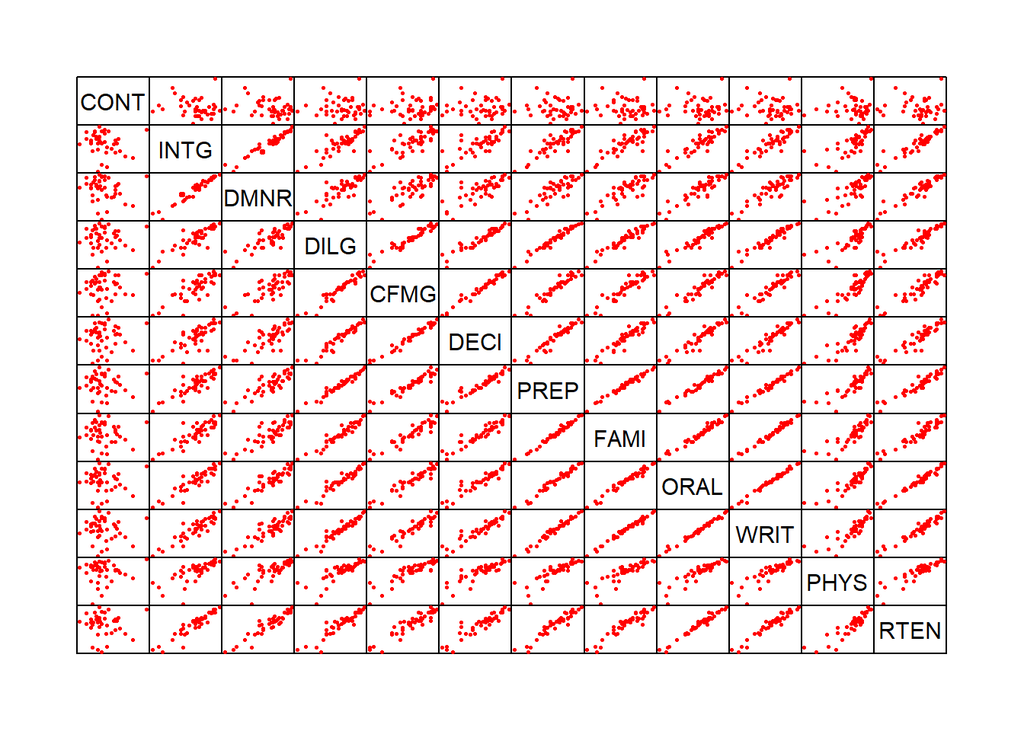

```r
pairs(
  USJudgeRatings,
  lwd = 1,
  pch = 16,
  cex = .5,
  col = "red",
  gap = 0,
  xaxt = "n",
  yaxt = "n"
)
```

b.Thực hiện phân tích thành phần chính cho dữ liệu:

```r
pca <- princomp(USJudgeRatings)
pca
```

```
## Call:
## princomp(x = USJudgeRatings)
##
## Standard deviations:
##     Comp.1     Comp.2     Comp.3     Comp.4     Comp.5     Comp.6     Comp.7
## 2.99448123 0.97631616 0.54821237 0.46436892 0.26089731 0.17209900 0.12744418
##     Comp.8     Comp.9    Comp.10    Comp.11    Comp.12
## 0.10741190 0.08622169 0.07038431 0.05505760 0.04345465
##
##  12  variables and  43 observations.
```

Tóm tắt kết quả:

```r
summary(pca)
```

```
## Importance of components:
##                           Comp.1     Comp.2     Comp.3     Comp.4      Comp.5
## Standard deviation     2.9944812 0.97631616 0.54821237 0.46436892 0.260897305
## Proportion of Variance 0.8476102 0.09010189 0.02840865 0.02038352 0.006434164
## Cumulative Proportion  0.8476102 0.93771205 0.96612070 0.98650423 0.992938391
##                             Comp.6      Comp.7      Comp.8       Comp.9
## Standard deviation     0.172098999 0.127444176 0.107411902 0.0862216855
## Proportion of Variance 0.002799688 0.001535299 0.001090581 0.0007027259
## Cumulative Proportion  0.995738079 0.997273378 0.998363959 0.9990666848
##                             Comp.10      Comp.11      Comp.12
## Standard deviation     0.0703843063 0.0550575991 0.0434546479
## Proportion of Variance 0.0004682789 0.0002865415 0.0001784947
## Cumulative Proportion  0.9995349638 0.9998215053 1.0000000000
```

#### **Bài 8.6**

Đọc dữ liệu

```r
library(datasets)
data("ability.cov")
head(ability.cov)
```

```
## $cov
##         general picture  blocks   maze reading   vocab
## general  24.641   5.991  33.520  6.023  20.755  29.701
## picture   5.991   6.700  18.137  1.782   4.936   7.204
## blocks   33.520  18.137 149.831 19.424  31.430  50.753
## maze      6.023   1.782  19.424 12.711   4.757   9.075
## reading  20.755   4.936  31.430  4.757  52.604  66.762
## vocab    29.701   7.204  50.753  9.075  66.762 135.292
##
## $center
## [1] 0 0 0 0 0 0
##
## $n.obs
## [1] 112
```

1. Thực hiện phân tích factor trên ma trận hiệp phương sai.

```r
factanal(factors = 2, covmat = ability.cov)
```

```
##
## Call:
## factanal(factors = 2, covmat = ability.cov)
##
## Uniquenesses:
## general picture  blocks    maze reading   vocab
##   0.455   0.589   0.218   0.769   0.052   0.334
##
## Loadings:
##         Factor1 Factor2
## general 0.499   0.543
## picture 0.156   0.622
## blocks  0.206   0.860
## maze    0.109   0.468
## reading 0.956   0.182
## vocab   0.785   0.225
##
##                Factor1 Factor2
## SS loadings      1.858   1.724
## Proportion Var   0.310   0.287
## Cumulative Var   0.310   0.597
##
## Test of the hypothesis that 2 factors are sufficient.
## The chi square statistic is 6.11 on 4 degrees of freedom.
## The p-value is 0.191
```

2. Thực hiện phân tích thành phần chính bằng các sử dụng ma trận hiệp phương sai. Sử dụng các loadings để xác định các biến nào được nhóm lại với nhau trong 2 factor đầu tiên

```r
ability.cor <- cov2cor(ability.cov$cov)
pc <- princomp(ability.cor)
summary(pc)
```

```
## Importance of components:
##                           Comp.1    Comp.2     Comp.3     Comp.4     Comp.5
## Standard deviation     0.4776241 0.3448660 0.19810024 0.15709576 0.08183170
## Proportion of Variance 0.5461757 0.2847480 0.09395716 0.05908658 0.01603257
## Cumulative Proportion  0.5461757 0.8309237 0.92488085 0.98396743 1.00000000
##                        Comp.6
## Standard deviation          0
## Proportion of Variance      0
## Cumulative Proportion       1
```

```r
pc$loadings
```

```
##
## Loadings:
##         Comp.1 Comp.2 Comp.3 Comp.4 Comp.5 Comp.6
## general  0.136  0.226  0.794  0.522  0.161
## picture -0.280  0.683 -0.284  0.157         0.589
## blocks  -0.263  0.252  0.499 -0.783
## maze    -0.366 -0.645  0.179                0.644
## reading  0.599                      -0.708  0.358
## vocab    0.584               -0.283  0.683  0.327
##
##                Comp.1 Comp.2 Comp.3 Comp.4 Comp.5 Comp.6
## SS loadings     1.000  1.000  1.000  1.000  1.000  1.000
## Proportion Var  0.167  0.167  0.167  0.167  0.167  0.167
## Cumulative Var  0.167  0.333  0.500  0.667  0.833  1.000
```

Kết luận:  
Trong Comp.1: reading(0.599) và vocab(0.584) có loadings dương tương đối lớn nên có xu hướng được nhóm lại với nhau  
Trong Comp.2: picture(0.683) và maze(-0.645) có loadings hướng ngược nhau tương đối lớn nên có xu hướng được nhóm lại với nhau  
d. Sử dụng ma trận tương quan phân tích thành phần chính của dữ liệu. Xem xét các loadings và diễn giải hai thành phần chính đầu tiên. So sánh với phần a, b và chỉ ra điểm khác biệt giữa chúng

```r
pc01 <- princomp(ability.cor)
pc01
```

```
## Call:
## princomp(x = ability.cor)
##
## Standard deviations:
##    Comp.1    Comp.2    Comp.3    Comp.4    Comp.5    Comp.6
## 0.4776241 0.3448660 0.1981002 0.1570958 0.0818317 0.0000000
##
##  6  variables and  6 observations.
```

```r
pc02 <- princomp(ability.cor)
pc02
```

```
## Call:
## princomp(x = ability.cor)
##
## Standard deviations:
##    Comp.1    Comp.2    Comp.3    Comp.4    Comp.5    Comp.6
## 0.4776241 0.3448660 0.1981002 0.1570958 0.0818317 0.0000000
##
##  6  variables and  6 observations.
```

```r
pc01$loadings
```

```
##
## Loadings:
##         Comp.1 Comp.2 Comp.3 Comp.4 Comp.5 Comp.6
## general  0.136  0.226  0.794  0.522  0.161
## picture -0.280  0.683 -0.284  0.157         0.589
## blocks  -0.263  0.252  0.499 -0.783
## maze    -0.366 -0.645  0.179                0.644
## reading  0.599                      -0.708  0.358
## vocab    0.584               -0.283  0.683  0.327
##
##                Comp.1 Comp.2 Comp.3 Comp.4 Comp.5 Comp.6
## SS loadings     1.000  1.000  1.000  1.000  1.000  1.000
## Proportion Var  0.167  0.167  0.167  0.167  0.167  0.167
## Cumulative Var  0.167  0.333  0.500  0.667  0.833  1.000
```

```r
pc02$loading
```

```
##
## Loadings:
##         Comp.1 Comp.2 Comp.3 Comp.4 Comp.5 Comp.6
## general  0.136  0.226  0.794  0.522  0.161
## picture -0.280  0.683 -0.284  0.157         0.589
## blocks  -0.263  0.252  0.499 -0.783
## maze    -0.366 -0.645  0.179                0.644
## reading  0.599                      -0.708  0.358
## vocab    0.584               -0.283  0.683  0.327
##
##                Comp.1 Comp.2 Comp.3 Comp.4 Comp.5 Comp.6
## SS loadings     1.000  1.000  1.000  1.000  1.000  1.000
## Proportion Var  0.167  0.167  0.167  0.167  0.167  0.167
## Cumulative Var  0.167  0.333  0.500  0.667  0.833  1.000
```

#### **Bài 8.9**

Đọc dữ liệu

```r
library(datasets)
data("trees")
head(data)
```

[output not shown]

1. Vẽ biểu đồ pairs

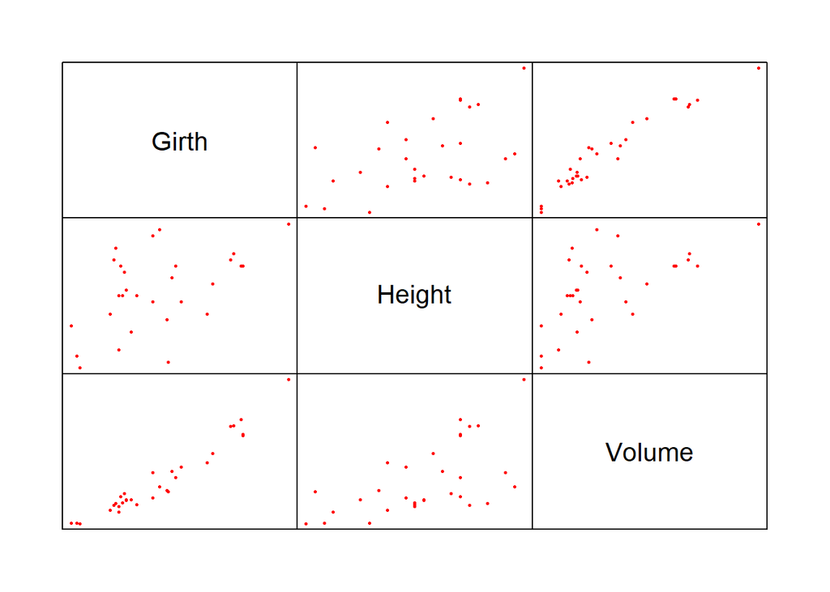

```r
pairs(
  trees,
  lwd = 1,
  pch = 16,
  cex = .5,
  col = "red",
  gap = 0,
  xaxt = "n",
  yaxt = "n"
)
```

b.  
Phân tích thành phần chính

```r
pcacor <- princomp(trees, cor = TRUE)
pcacor
```

```
## Call:
## princomp(x = trees, cor = TRUE)
##
## Standard deviations:
##    Comp.1    Comp.2    Comp.3
## 1.5525141 0.7494113 0.1675789
##
##  3  variables and  31 observations.
```

Dựa trên kết quả phân tích thành phần chính xem cách các biến ban đầu tương quan với các thành phần chính

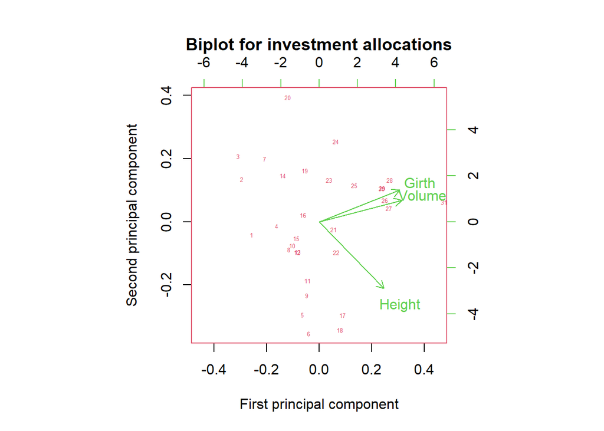

```r
biplot(
  pcacor,
  col = c(2, 3),
  cex = c(.4, 1),
  xlim = c( -.45, .45),
  xlab = "First principal component",
  ylab = "Second principal component",
  main = "Biplot for investment allocations"
)
```

Xác định các ngoại lệ trong dữ liệu

```r
outliers <- which(rowSums((trees - pcacor$center)^2) > 3 * sum(pcacor$sdev^2) / length(pcacor$sdev))
if(length(outliers) > 0) {
  print("Outliers:")
  print(trees[outliers, ])
} else {
  print("No outliers.")
}
```

```
## [1] "Outliers:"
##    Girth Height Volume
## 1    8.3     70   10.3
## 2    8.6     65   10.3
## 3    8.8     63   10.2
## 4   10.5     72   16.4
## 5   10.7     81   18.8
## 6   10.8     83   19.7
## 7   11.0     66   15.6
## 8   11.0     75   18.2
## 9   11.1     80   22.6
## 10  11.2     75   19.9
## 11  11.3     79   24.2
## 12  11.4     76   21.0
## 13  11.4     76   21.4
```

[output cut: 18 more lines]